# Curve fitting

Jack Brookes

21 March 2018

Info from [here](http://www.css.cornell.edu/faculty/dgr2/teach/R/R_CurveFit.pdf).

## Create example data

Create data from a function `y = a * e^(b * x) + c + noise`.

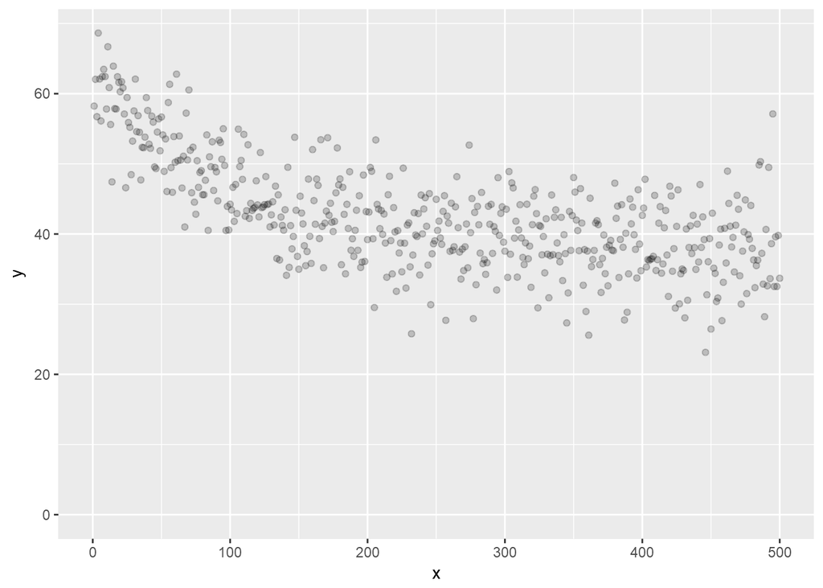

```r
# tibbles instead of data.frame for cleaner syntax
# includes ggplot2
library(tidyverse)

a <- 23.7
b <- -0.01
c <- 37.9

set.seed(1) #reproducible

example_data <- tibble(
  x = 1:500,
  y = a * exp(b * x) + c + rnorm(500, 0, 5)
)

g <- ggplot(example_data, aes(x, y)) +
  geom_point(alpha = .2) +
  expand_limits(x = 0, y = 0)

g
```

## Exponential fit

Here we will use the `nls` (Nonlinear Least Squares) function to estimate some parameters for an exponential model. We will assume the form `y = a * e^(b * x) + c`. We can set the trace to `TRUE` to see how the algorithm attempts to find the parameters. We could also use `lower` and `upper` parameters to set bounds on our estimates of the coefficients (run `?nls`).

```r
exp_model <- nls(y ~ a * exp(b * x) + c, data = example_data, start = list(a = 1, b = 1, c = 1), trace = TRUE)
```

```
## Inf :  1 1 1
## Inf :    2.779366e-06   1.000000e+00 -1.490282e+185
## Inf :   -1.490958e-12   1.000000e+00  1.140191e+191
## Inf :   -4.124165e-18   1.000000e+00  1.725187e+191
## Inf :   -1.230131e-23   1.000000e+00  7.477957e+187
## Inf :    4.630765e-29   1.000000e+00 -4.844672e+182
## Inf :    1.029108e-34   1.000000e+00 -5.930485e+176
## Inf :   -8.193268e-41   1.000000e+00 -9.817949e+170
## Inf :    3.57422e-46   1.00000e+00 -4.68593e+165
## Inf :   -6.298201e-52   1.000000e+00  5.683653e+159
## Inf :   -1.400974e-58   1.000000e+00  1.519829e+153
## 5.237138e+306 :    1.516109e-64   1.000000e+00 -4.059431e+147
## 8.049291e+294 :    1.879589e-70   1.000000e+00 -5.786018e+141
## 8.158728e+281 :   5.984027e-77  1.000000e+00 9.876361e+134
## 6.112797e+269 :   -5.179678e-83   1.000000e+00  1.544031e+128
## 1.758065e+257 :   -2.777795e-89   1.000000e+00 -4.578569e+121
## 2.629482e+245 :    3.397179e-95   1.000000e+00 -7.810888e+116
## 6.718016e+232 :  -1.717140e-101   1.000000e+00  1.297536e+111
## 3.19294e+220 :   1.183798e-107   1.000000e+00 -1.497102e+104
## 3.154732e+208 :   1.176695e-113   1.000000e+00  -1.330234e+98
## 1.84454e+196 :  -8.997606e-120   1.000000e+00   2.229427e+92
## 1.162167e+184 :   7.141950e-126   1.000000e+00  -1.493661e+86
## 2.897853e+172 :  -1.127770e-131   1.000000e+00   3.355787e+80
## 3.083854e+160 :   1.163397e-137   1.000000e+00  -1.386364e+74
## 1.723466e+149 :  -2.750308e-143   1.000000e+00   4.070487e+68
## 3.748853e+137 :  -4.056295e-149   1.000000e+00   2.172452e+62
## 3.257501e+126 :  -1.195706e-154   1.000000e+00   1.971698e+57
## 7.245989e+112 :  1.783321e-161  1.000000e+00  2.175654e+50
## 1.088806e+102 :   6.912874e-167   1.000000e+00  -6.768699e+44
## 5.374782e+87 :  -4.856979e-174   1.000000e+00   3.299454e+38
## 1.550033e+77 :   2.608265e-179   1.000000e+00  -3.819806e+32
## 1.08776e+67 :   2.184999e-184   1.000000e+00  -2.566676e+27
## 4.289769e+55 :   4.339129e-190   1.000000e+00  -5.424943e+21
## 5.24377e+44 :   1.517082e-195   1.000000e+00  -2.179842e+16
## 4.231805e+34 :  -1.362844e-200   1.000000e+00   1.749396e+11
## 6.002008e+23 :   5.132513e-206   1.000000e+00  -8.630624e+05
## 1.370804e+13 :  -2.452835e-211   1.000000e+00   4.516087e+01
## 53921139 :  -4.880299e-214   9.999960e-01   4.274843e+01
## 7308222 :  -4.878564e-214   9.979991e-01   4.274841e+01
## 261382.2 :  -1.320396e-213   9.925925e-01   4.274847e+01
## 30622 :  -1.956274e-212   9.629962e-01   4.274864e+01
```

```
## Error in nls(y ~ a * exp(b * x) + c, data = example_data, start = list(a = 1, : singular gradient
```

The algorithm didn’t find a solution, we need to provide better initial estimates. If we look at the graph, we can see some kind of floor effect at high values of `x`, where the floor is around `y = 40`. So we can make a guess of `c = 40`. Then, at `x = 0`, it looks like `y ~= 60`. If we put these into our formula (`60 = a * e^(b * 0) + 40`) we get `a = 20`. We also know that the value of `y` decreases as `x` increases, so `b` must be negative. Now we try these new guesses:

```r
exp_model <- nls(y ~ a * exp(b * x) + c, data = example_data, start = list(a = 20, b = -1, c = 40), trace = TRUE)
```

```
## 33871.6 :  20 -1 40
```

```
## Error in numericDeriv(form[[3L]], names(ind), env): Missing value or an infinity produced when evaluating the model
```

We still get an error. If you plot our assumed formula in something like [Desmos](https://www.desmos.com/calculator/40leuwa8mx), the graph looks very different to ours, it is very steep. So we can try a smaller gradient (`b`).

```r
exp_model <- nls(y ~ a * exp(b * x) + c, data = example_data, start = list(a = 20, b = -0.1, c = 40), trace = TRUE)
```

```
## 28509.58 :  20.0 -0.1 40.0
## 18237.88 :  16.03433315 -0.02107305 40.33933094
## 14644.91 :  18.694970189 -0.008082207 39.578002795
## 12770.45 :  24.13680444 -0.01053179 38.13190398
## 12757.92 :  24.50718252 -0.01018671 37.94686590
## 12757.9 :  24.51211176 -0.01019428 37.94251313
```

It converged and found the three values.

```r
summary(exp_model)
```

```
##
## Formula: y ~ a * exp(b * x) + c
##
## Parameters:
##     Estimate Std. Error t value Pr(>|t|)
## a 24.5121118  1.0353559   23.68   <2e-16 ***
## b -0.0101943  0.0009122  -11.18   <2e-16 ***
## c 37.9425131  0.4358450   87.06   <2e-16 ***
## ---
## Signif. codes:  0 '***' 0.001 '**' 0.01 '*' 0.05 '.' 0.1 ' ' 1
##
## Residual standard error: 5.067 on 497 degrees of freedom
##
## Number of iterations to convergence: 5
## Achieved convergence tolerance: 4.204e-06
```

## Power fit

Same approach… `I()` is used here because `^` has a special meaning in a stats formula, but we want to use its mathematical meaning (“to the power of”). We assume a power formula (`y = a * x^b + c`). It’s more difficult to guess the initial values here. In this formula, `c` is the y-intercept, so we could first guess `c = 60`.

```r
pow_model <- nls(y ~ a * I(x ^ b) + c, data = example_data, start = list(a = 1, b = 1, c = 60), trace = TRUE)
```

```
## 47045658 :   1  1 60
## 13660771 :  -0.4394207  1.0632696 62.1857775
## 1404461 :  -0.3111440  0.9602111 61.2684086
## 56642.72 :  -0.5453078  0.7097977 62.8097169
## 40995.61 :  -1.3097525  0.4571029 65.3570447
## 40419.79 :  -1.5095426  0.4364405 65.7210265
## 39805.65 :  -1.730165  0.416943 66.107746
## 39158 :  -1.9722521  0.3985661 66.5169332
## 38481.77 :  -2.2362889  0.3812621 66.9482454
## 37781.91 :  -2.522605  0.364981 67.401269
## 37063.21 :  -2.8313769  0.3496714 67.8755179
## 36949.46 :  -3.4938877  0.3208925 68.8653607
## 36558.56 :  -4.2511765  0.2952569 69.9399899
## 35927.19 :  -5.1018656  0.2725202 71.0949270
## 35097.08 :  -6.0420210  0.2524169 72.3240840
## 34111.25 :  -7.0654264  0.2346781 73.6199132
## 33011.16 :  -8.163955  0.219043 74.973632
## 32923.16 :  -10.4920403   0.1914916  77.7773735
## 31805.36 :  -13.0572668   0.1699929  80.7479656
## 30005.43 :  -15.7596580   0.1533636  83.7911990
## 29136.36 :  -21.2311190   0.1277113  89.8309839
## 27561.94 :  -31.60474981   0.09841312 100.94662285
## 13968.71 :  -43.82325007   0.08881615 113.58298352
## 13494.84 :  -42.09867723   0.09381536 111.73532198
## 13493.71 :  -43.24660976   0.09212234 112.94843444
## 13493.61 :  -42.92607262   0.09263826 112.60607165
## 13493.61 :  -43.03061663   0.09248217 112.71729425
## 13493.61 :  -42.99964620   0.09252935 112.68430621
## 13493.61 :  -43.00907681   0.09251508 112.69434756
```

This looks like it worked. We can verify and play around [here](https://www.desmos.com/calculator/ueecjzmmbw).

## Compare

Lets plot the two models on top of our original graph. We can extract the coefficients to out model using `coef()` and converting to a list for easier access. Then we can use that to create a smooth line for both models.

```r
exp_coeffs <- as.list(coef(exp_model))

exp_line <- tibble(
  model = "exp",
  x = 1:500,
  y = exp_coeffs$a * exp(exp_coeffs$b * x) + exp_coeffs$c
)

exp_coeffs
```

```
## $a
## [1] 24.51211
##
## $b
## [1] -0.01019428
##
## $c
## [1] 37.94251
```

```r
pow_coeffs <- as.list(coef(pow_model))

pow_line <- tibble(
  model = "pow",
  x = 1:500,
  y = pow_coeffs$a * x ^ pow_coeffs$b + pow_coeffs$c
)

pow_coeffs
```

```
## $a
## [1] -43.00908
##
## $b
## [1] 0.09251508
##
## $c
## [1] 112.6943
```

Add the lines to the plot

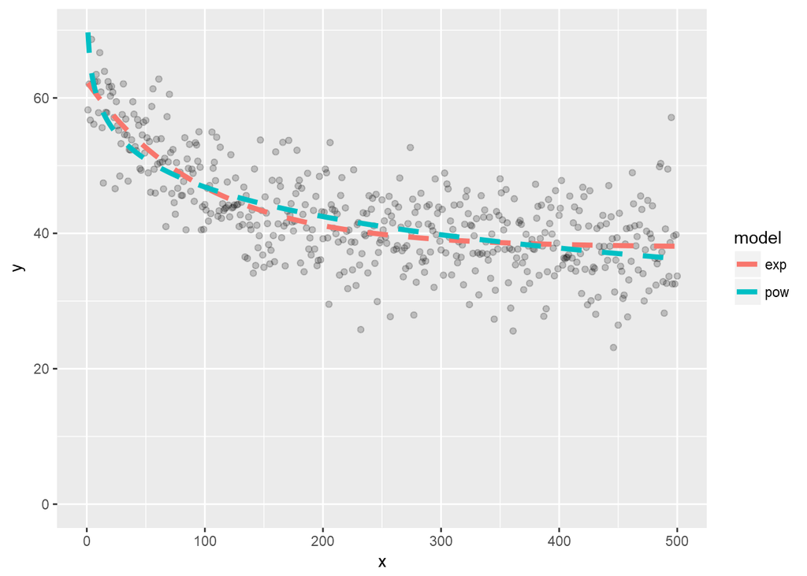

```r
g +
  geom_line(
    aes(x, y, color = model),
    data = bind_rows(exp_line, pow_line),
    size = 1.5,
    linetype = "dashed"
  )
```